# Unsupervised Learning

Machine Learning in Economics

Prof. Dr. Hüseyin Taştan

Yildiz Technical University

Spring 2021

# 1 Principal Components

We will use `USArrests` data set which is a part of the base `R`.

```r
library(ISLR)
states <- row.names(USArrests)
names(USArrests)
```

```
## [1] "Murder"   "Assault"  "UrbanPop" "Rape"
```

```r
apply(USArrests, 2, mean)
```

```
##   Murder  Assault UrbanPop     Rape
##    7.788  170.760   65.540   21.232
```

```r
apply(USArrests, 2, var)
```

```
##     Murder    Assault   UrbanPop       Rape
##   18.97047 6945.16571  209.51878   87.72916
```

There are several packages to conduct PCA analysis (`prcomp`, `princomp`, etc.) We standardize each variable using the option `scale=TRUE`

```r
pr.out <- prcomp(USArrests, scale=TRUE)
names(pr.out)
```

```
## [1] "sdev"     "rotation" "center"   "scale"    "x"
```

The center and scale components correspond to the means and standard deviations of the variables that were used for scaling prior to implementing PCA.

```r
pr.out$center
```

```
##   Murder  Assault UrbanPop     Rape
##    7.788  170.760   65.540   21.232
```

```r
pr.out$scale
```

```
##    Murder   Assault  UrbanPop      Rape
##  4.355510 83.337661 14.474763  9.366385
```

The `rotation` matrix provides the principal component loadings; each column of `pr.out$rotation` contains the corresponding principal component loading vector

```r
pr.out$rotation
```

```
##                 PC1        PC2        PC3         PC4
## Murder   -0.5358995  0.4181809 -0.3412327  0.64922780
## Assault  -0.5831836  0.1879856 -0.2681484 -0.74340748
## UrbanPop -0.2781909 -0.8728062 -0.3780158  0.13387773
## Rape     -0.5434321 -0.1673186  0.8177779  0.08902432
```

Principle component score vectors:

```r
dim(pr.out$x)
```

```
## [1] 50  4
```

We can plot the first two principal components as follows

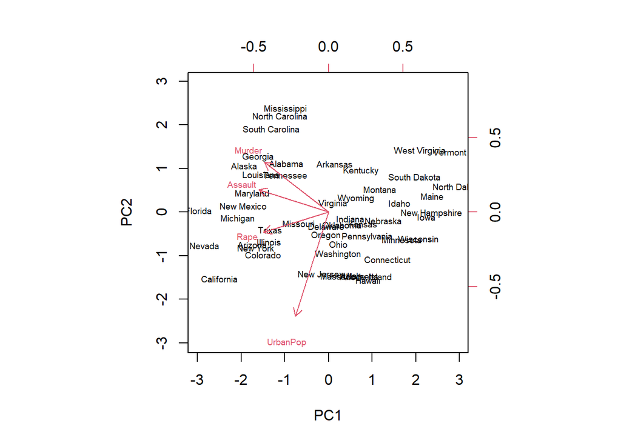

```r
biplot(pr.out, scale=0, cex=0.6)
```

The `scale=0` argument to `biplot()` ensures that the arrows are scaled to represent the loadings; other values for scale give slightly different biplots with different interpretations.

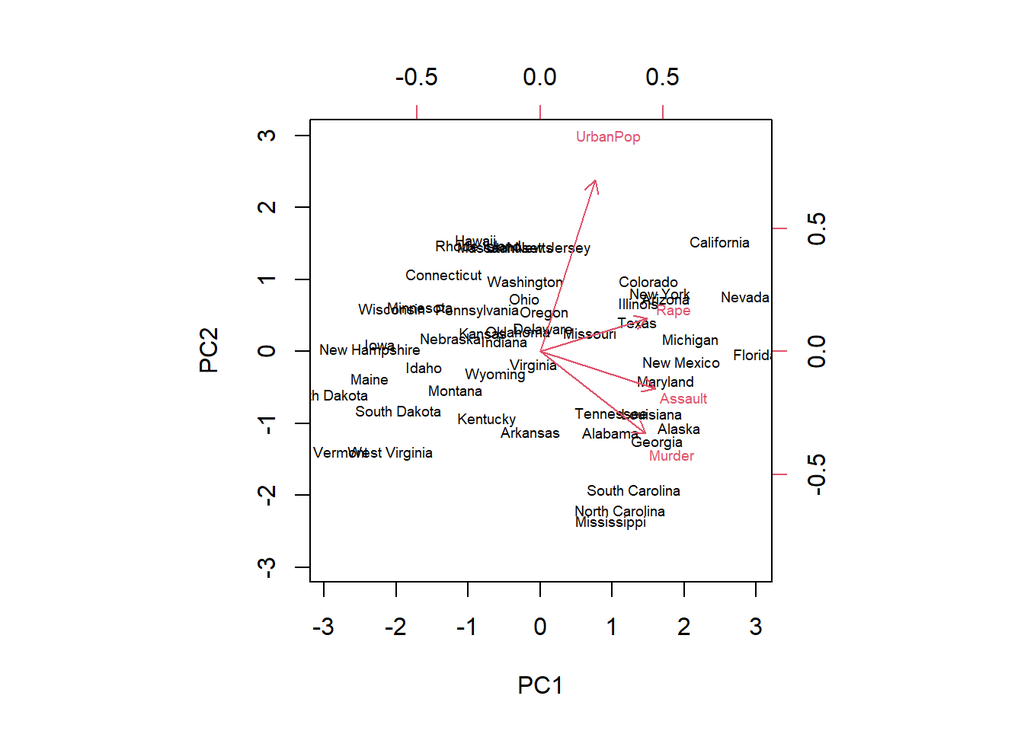

```r
pr.out$rotation <- -pr.out$rotation
pr.out$x <- -pr.out$x
biplot(pr.out, scale=0, cex=0.6)
```

Importance of principal components:

```r
summary(pr.out)
```

```
## Importance of components:
##                           PC1    PC2     PC3     PC4
## Standard deviation     1.5749 0.9949 0.59713 0.41645
## Proportion of Variance 0.6201 0.2474 0.08914 0.04336
## Cumulative Proportion  0.6201 0.8675 0.95664 1.00000
```

We see that the first principal component explains 62.0% of the variance in the data, the next principal component explains 24.7% of the variance, and so forth.

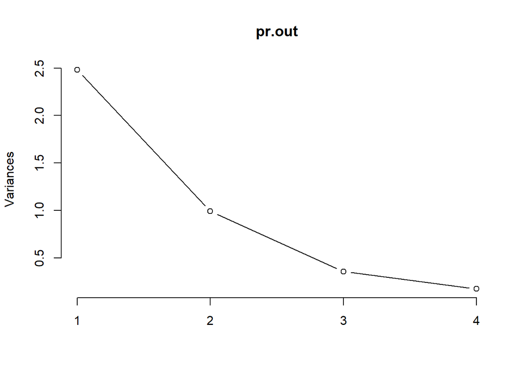

```r
screeplot(pr.out, type="lines")
```

```r
pr.out$sdev
```

```
## [1] 1.5748783 0.9948694 0.5971291 0.4164494
```

```r
pr.var <- pr.out$sdev^2
pr.var
```

```
## [1] 2.4802416 0.9897652 0.3565632 0.1734301
```

```r
pve <- pr.var/sum(pr.var)
pve
```

```
## [1] 0.62006039 0.24744129 0.08914080 0.04335752
```

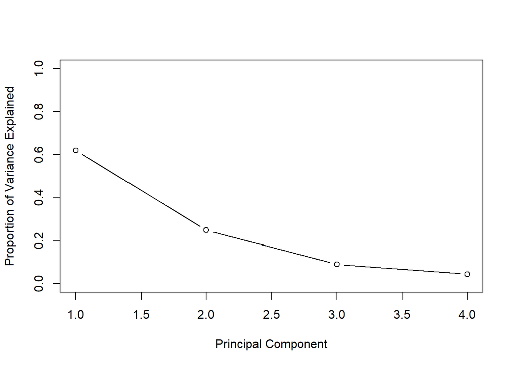

```r
plot(pve, xlab="Principal Component", ylab="Proportion of Variance Explained", ylim=c(0,1),type='b')
```

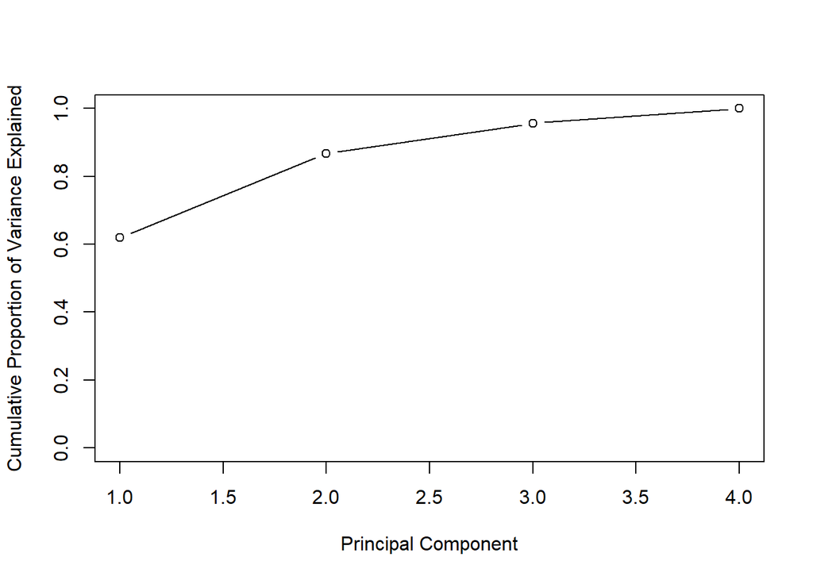

```r
plot(cumsum(pve), xlab="Principal Component", ylab="Cumulative Proportion of Variance Explained", ylim=c(0,1),type='b')
```

## 1.1 Example: Body Data

This data set contains a set of body measurements along with age, height, weight and gender on 507 individuals (247 men 260 women). We expect some of these variables to be highly correlated.

```r
# body data from
# Journal of Statistics Education Volume 11, Number 2 (2003),
# www.amstat.org/publications/jse/v11n2/datasets.heinz.html

load("../Data/body.RData")
bodydata <- subset(body, select = -c(age, gender, gender_dummy))
str(bodydata)
```

```
## Classes 'spec_tbl_df', 'tbl_df', 'tbl' and 'data.frame': 507 obs. of  23 variables:
##  $ biacromial_diameter    : num  42.9 43.7 40.1 44.3 42.5 43.3 43.5 44.4 43.5 42 ...
##  $ biiliac_diameter       : num  26 28.5 28.2 29.9 29.9 27 30 29.8 26.5 28 ...
##  $ bitrochanteric_diameter: num  31.5 33.5 33.3 34 34 31.5 34 33.2 32.1 34 ...
##  $ chest_depth            : num  17.7 16.9 20.9 18.4 21.5 19.6 21.9 21.8 15.5 22.5 ...
##  $ chest_diameter         : num  28 30.8 31.7 28.2 29.4 31.3 31.7 28.8 27.5 28 ...
##  $ elbow_diameter         : num  13.1 14 13.9 13.9 15.2 14 16.1 15.1 14.1 15.6 ...
##  $ wrist_diameter         : num  10.4 11.8 10.9 11.2 11.6 11.5 12.5 11.9 11.2 12 ...
##  $ knee_diameter          : num  18.8 20.6 19.7 20.9 20.7 18.8 20.8 21 18.9 21.1 ...
##  $ ankle_diameter         : num  14.1 15.1 14.1 15 14.9 13.9 15.6 14.6 13.2 15 ...
##  $ shoulder_girth         : num  106 110 115 104 108 ...
##  $ chest_girth            : num  89.5 97 97.5 97 97.5 ...
##  $ waist_girth            : num  71.5 79 83.2 77.8 80 82.5 82 76.8 68.5 77.5 ...
##  $ abdominal_girth        : num  74.5 86.5 82.9 78.8 82.5 80.1 84 80.5 69 81.5 ...
##  $ hip_girth              : num  93.5 94.8 95 94 98.5 95.3 101 98 89.5 99.8 ...
##  $ thigh_girth            : num  51.5 51.5 57.3 53 55.4 57.5 60.9 56 50 59.8 ...
##  $ bicep_girth            : num  32.5 34.4 33.4 31 32 33 42.4 34.1 33 36.5 ...
##  $ forearm_girth          : num  26 28 28.8 26.2 28.4 28 32.3 28 26 29.2 ...
##  $ knee_girth             : num  34.5 36.5 37 37 37.7 36.6 40.1 39.2 35.5 38.3 ...
##  $ calf_girth             : num  36.5 37.5 37.3 34.8 38.6 36.1 40.3 36.7 35 38.6 ...
##  $ ankle_girth            : num  23.5 24.5 21.9 23 24.4 23.5 23.6 22.5 22 22.2 ...
##  $ wrist_girth            : num  16.5 17 16.9 16.6 18 16.9 18.8 18 16.5 16.9 ...
##  $ weight                 : num  65.6 71.8 80.7 72.6 78.8 74.8 86.4 78.4 62 81.6 ...
##  $ height                 : num  174 175 194 186 187 ...
```

Inspecting the correlation matrix we see that these features are in fact highly correlated.

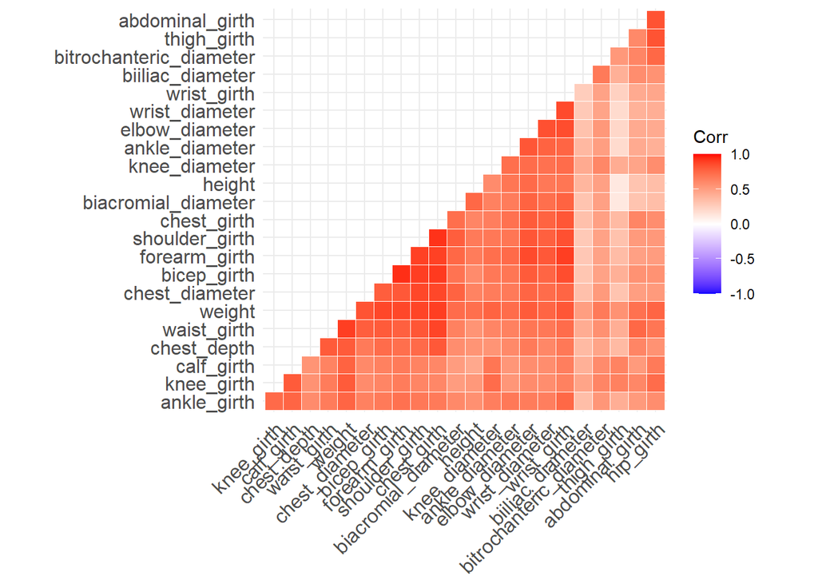

```r
library(ggcorrplot)
cormat <- round(cor(bodydata), 2)
ggcorrplot(cormat, hc.order = TRUE, type = "lower", outline.color = "white")
```

Find the principal components:

```r
pr.out <- prcomp(bodydata, scale=TRUE)
summary(pr.out)
```

```
## Importance of components:
##                           PC1    PC2     PC3     PC4     PC5     PC6     PC7
## Standard deviation     3.8644 1.5758 1.03211 0.95475 0.69342 0.65851 0.58162
## Proportion of Variance 0.6493 0.1080 0.04632 0.03963 0.02091 0.01885 0.01471
## Cumulative Proportion  0.6493 0.7572 0.80357 0.84320 0.86410 0.88296 0.89767
##                           PC8     PC9    PC10    PC11    PC12    PC13    PC14
## Standard deviation     0.5674 0.52727 0.52186 0.49794 0.45082 0.42002 0.39670
## Proportion of Variance 0.0140 0.01209 0.01184 0.01078 0.00884 0.00767 0.00684
## Cumulative Proportion  0.9117 0.92375 0.93559 0.94637 0.95521 0.96288 0.96972
##                           PC15   PC16    PC17    PC18   PC19    PC20    PC21
## Standard deviation     0.38094 0.3490 0.32002 0.29400 0.2835 0.23619 0.21552
## Proportion of Variance 0.00631 0.0053 0.00445 0.00376 0.0035 0.00243 0.00202
## Cumulative Proportion  0.97603 0.9813 0.98578 0.98954 0.9930 0.99546 0.99748
##                           PC22   PC23
## Standard deviation     0.19313 0.1437
## Proportion of Variance 0.00162 0.0009
## Cumulative Proportion  0.99910 1.0000
```

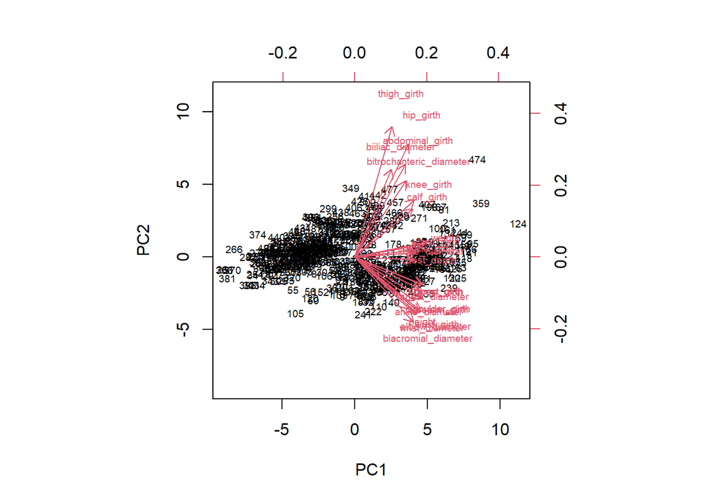

```r
# change the signs of factor loadings
pr.out$rotation <- -pr.out$rotation
pr.out$x <- -pr.out$x
biplot(pr.out, scale=0, cex=0.6)
```

```r
pr.var <- pr.out$sdev^2
pve <- pr.var/sum(pr.var)
pve
```

```
##  [1] 0.6492846086 0.1079652790 0.0463153491 0.0396329172 0.0209057316
##  [6] 0.0188539644 0.0147079693 0.0139999780 0.0120875732 0.0118406532
## [11] 0.0107802578 0.0088363210 0.0076704395 0.0068423027 0.0063093336
## [16] 0.0052965553 0.0044528583 0.0037581598 0.0034951865 0.0024254119
## [21] 0.0020194249 0.0016217326 0.0008979928
```

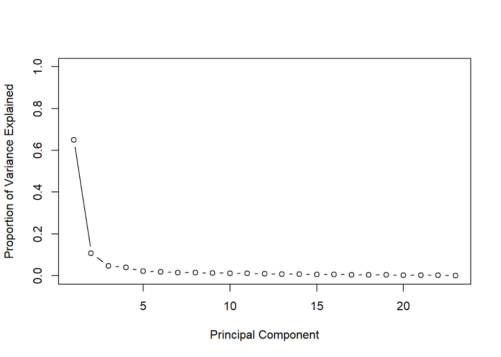

```r
plot(pve, xlab="Principal Component", ylab="Proportion of Variance Explained", ylim=c(0,1),type='b')
```

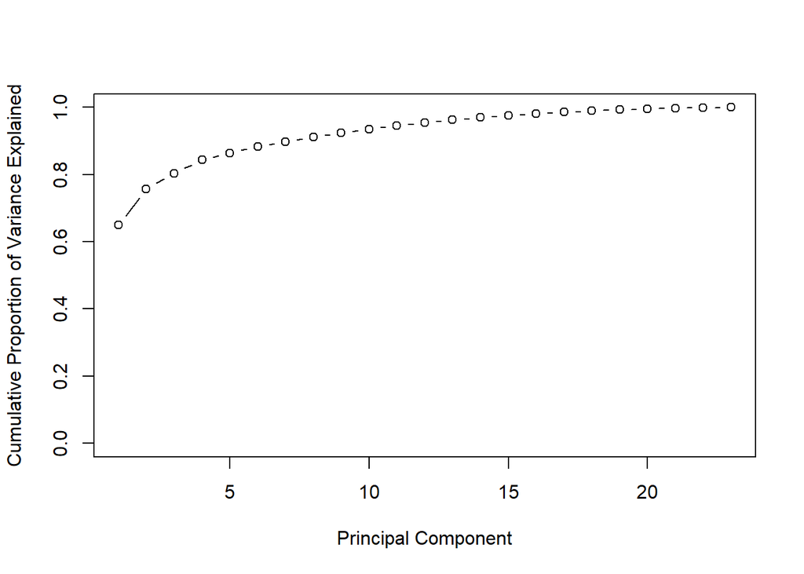

```r
plot(cumsum(pve), xlab="Principal Component", ylab="Cumulative Proportion of Variance Explained", ylim=c(0,1),type='b')
```

Approximately 85% of the total variation can be explained by the first 5 principal components.

## 1.2 Example: Regional Happiness Indicators

```r
load("../Data/lifedata2015.RData")
pr_happiness <- prcomp(lifedata2015[,-1], scale=TRUE)
summary(pr_happiness)
```

```
## Importance of components:
##                           PC1    PC2     PC3     PC4     PC5     PC6     PC7
## Standard deviation     3.6487 2.7994 1.61778 1.44839 1.31128 1.23677 1.08694
## Proportion of Variance 0.3247 0.1911 0.06383 0.05117 0.04194 0.03731 0.02882
## Cumulative Proportion  0.3247 0.5158 0.57968 0.63084 0.67278 0.71009 0.73890
##                            PC8     PC9    PC10   PC11    PC12    PC13    PC14
## Standard deviation     1.05930 0.99654 0.94201 0.9034 0.84682 0.78979 0.76944
## Proportion of Variance 0.02737 0.02422 0.02164 0.0199 0.01749 0.01521 0.01444
## Cumulative Proportion  0.76627 0.79049 0.81214 0.8320 0.84953 0.86474 0.87918
##                           PC15   PC16   PC17    PC18    PC19    PC20    PC21
## Standard deviation     0.76204 0.7189 0.6500 0.63497 0.59349 0.55320 0.51029
## Proportion of Variance 0.01416 0.0126 0.0103 0.00983 0.00859 0.00746 0.00635
## Cumulative Proportion  0.89335 0.9060 0.9163 0.92609 0.93468 0.94215 0.94850
##                          PC22    PC23    PC24    PC25    PC26    PC27    PC28
## Standard deviation     0.4958 0.48471 0.45005 0.43610 0.40353 0.39223 0.36695
## Proportion of Variance 0.0060 0.00573 0.00494 0.00464 0.00397 0.00375 0.00328
## Cumulative Proportion  0.9545 0.96022 0.96516 0.96980 0.97377 0.97752 0.98081
##                           PC29    PC30    PC31   PC32    PC33    PC34    PC35
## Standard deviation     0.33688 0.33084 0.30826 0.2862 0.27626 0.26303 0.24261
## Proportion of Variance 0.00277 0.00267 0.00232 0.0020 0.00186 0.00169 0.00144
## Cumulative Proportion  0.98358 0.98625 0.98856 0.9906 0.99242 0.99411 0.99555
##                           PC36   PC37    PC38    PC39    PC40    PC41
## Standard deviation     0.22405 0.1925 0.17796 0.16091 0.15358 0.11901
## Proportion of Variance 0.00122 0.0009 0.00077 0.00063 0.00058 0.00035
## Cumulative Proportion  0.99677 0.9977 0.99845 0.99908 0.99965 1.00000
```

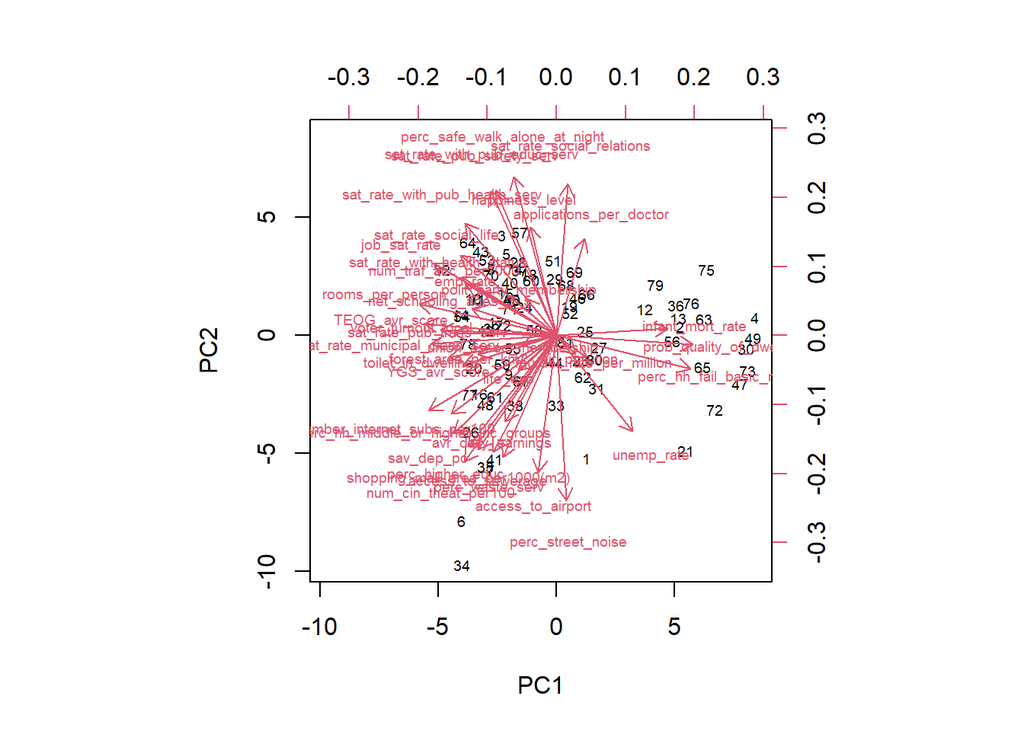

```r
# change the signs of factor loadings
pr_happiness$rotation <- -pr_happiness$rotation
pr_happiness$x <- -pr_happiness$x
biplot(pr_happiness, scale=0, cex=0.6)
```

```r
pr.var <- pr_happiness$sdev^2
pve <- pr.var/sum(pr.var)
pve
```

```
##  [1] 0.3247032515 0.1911377271 0.0638347339 0.0511669356 0.0419376566
##  [6] 0.0373075532 0.0288154928 0.0273685063 0.0242215157 0.0216434975
## [11] 0.0199036321 0.0174903839 0.0152139590 0.0144399072 0.0141635465
## [16] 0.0126038973 0.0103042710 0.0098339512 0.0085909019 0.0074641692
## [21] 0.0063510649 0.0059953400 0.0057303036 0.0049400620 0.0046386738
## [26] 0.0039715287 0.0037522269 0.0032841890 0.0027679669 0.0026696605
## [31] 0.0023177290 0.0019980467 0.0018614512 0.0016873924 0.0014356089
## [36] 0.0012243745 0.0009042744 0.0007723912 0.0006314968 0.0005752529
## [41] 0.0003454763
```

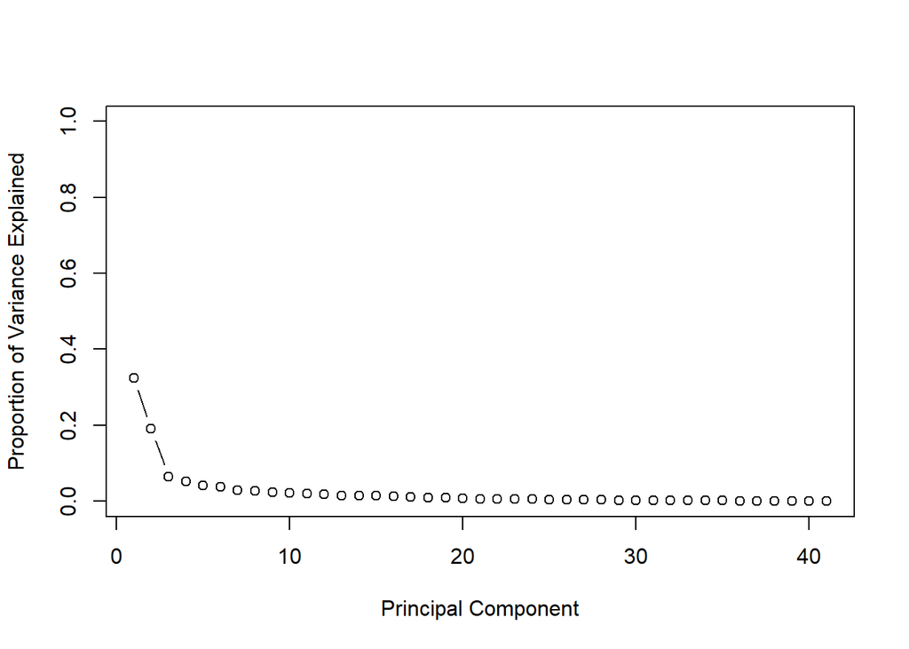

```r
plot(pve, xlab="Principal Component", ylab="Proportion of Variance Explained", ylim=c(0,1),type='b')
```

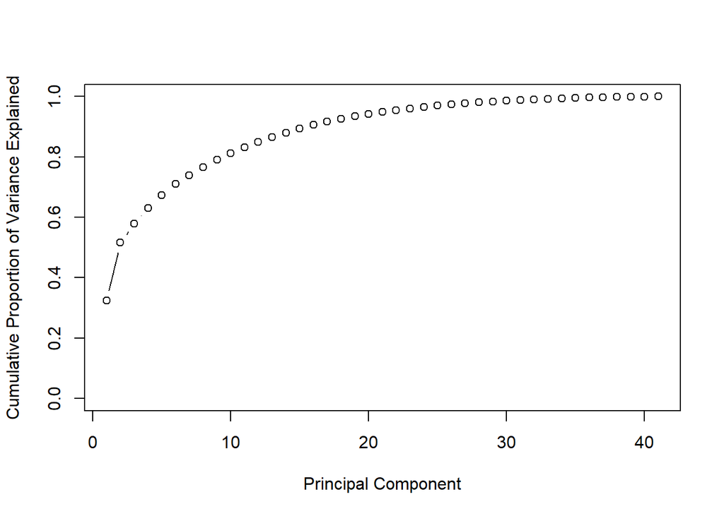

```r
plot(cumsum(pve), xlab="Principal Component", ylab="Cumulative Proportion of Variance Explained", ylim=c(0,1),type='b')
```

Approximately 80% of the variation in the data can be explained by the first 10 principal components.

### 1.2.1 Principal Components Regression (PCR)

Let’s apply PCR approach to the regional happiness data. We want to predict provincial happiness levels using the first few principal components.

We can use `pcr()` function in the `{pls}` package for that purpose.

```r
library(pls)
set.seed(123)

pcr_fit <- pcr(happiness_level ~ . -province,
               data = lifedata2015,
               scale=TRUE,
               validation="LOO")
summary(pcr_fit)
```

```
## Data:    X dimension: 81 40
##  Y dimension: 81 1
## Fit method: svdpc
## Number of components considered: 40
##
## VALIDATION: RMSEP
## Cross-validated using 81 leave-one-out segments.
##        (Intercept)  1 comps  2 comps  3 comps  4 comps  5 comps  6 comps
## CV            7.58    7.590    6.696    6.850    6.363    6.042    5.698
## adjCV         7.58    7.589    6.694    6.849    6.361    6.013    5.691
##        7 comps  8 comps  9 comps  10 comps  11 comps  12 comps  13 comps
## CV       5.744    5.565    5.438     5.108     5.056     5.191     5.114
## adjCV    5.744    5.557    5.431     5.090     5.047     5.185     5.102
##        14 comps  15 comps  16 comps  17 comps  18 comps  19 comps  20 comps
## CV        5.148     5.425     5.550     5.693     5.341     4.828     4.835
## adjCV     5.137     5.420     5.542     5.691     5.286     4.815     4.825
##        21 comps  22 comps  23 comps  24 comps  25 comps  26 comps  27 comps
## CV        4.857     4.903     4.981     5.068     5.231     5.398     5.404
## adjCV     4.847     4.897     4.970     5.058     5.220     5.387     5.392
##        28 comps  29 comps  30 comps  31 comps  32 comps  33 comps  34 comps
## CV        5.443     5.588     5.636     5.613     5.804     5.994     6.185
## adjCV     5.429     5.576     5.620     5.598     5.788     5.977     6.167
##        35 comps  36 comps  37 comps  38 comps  39 comps  40 comps
## CV        6.496     6.618     6.851     6.501     6.848     7.309
## adjCV     6.476     6.597     6.837     6.473     6.824     7.282
##
## TRAINING: % variance explained
##                  1 comps  2 comps  3 comps  4 comps  5 comps  6 comps  7 comps
## X                 33.217    52.13    58.61    63.06    67.28    71.10    73.98
## happiness_level    2.339    26.62    27.94    44.79    55.72    56.07    57.85
##                  8 comps  9 comps  10 comps  11 comps  12 comps  13 comps
## X                  76.73    79.16     81.31     83.35     85.13     86.65
## happiness_level    60.82    63.14     66.85     67.15     67.50     68.60
##                  14 comps  15 comps  16 comps  17 comps  18 comps  19 comps
## X                   88.12     89.57     90.80     91.83     92.74     93.62
## happiness_level     69.02     69.44     71.35     71.63     77.56     77.60
##                  20 comps  21 comps  22 comps  23 comps  24 comps  25 comps
## X                   94.39     95.04     95.65     96.23     96.73     97.20
## happiness_level     77.63     77.71     77.72     78.16     78.24     78.46
##                  26 comps  27 comps  28 comps  29 comps  30 comps  31 comps
## X                   97.59     97.93     98.26     98.54     98.78     99.02
## happiness_level     78.53     79.28     79.89     79.91     80.54     80.80
##                  32 comps  33 comps  34 comps  35 comps  36 comps  37 comps
## X                   99.21     99.38     99.53     99.66     99.75     99.83
## happiness_level     80.81     80.84     80.93     81.07     81.07     81.12
##                  38 comps  39 comps  40 comps
## X                   99.90     99.96    100.00
## happiness_level     83.24     83.38     83.65
```

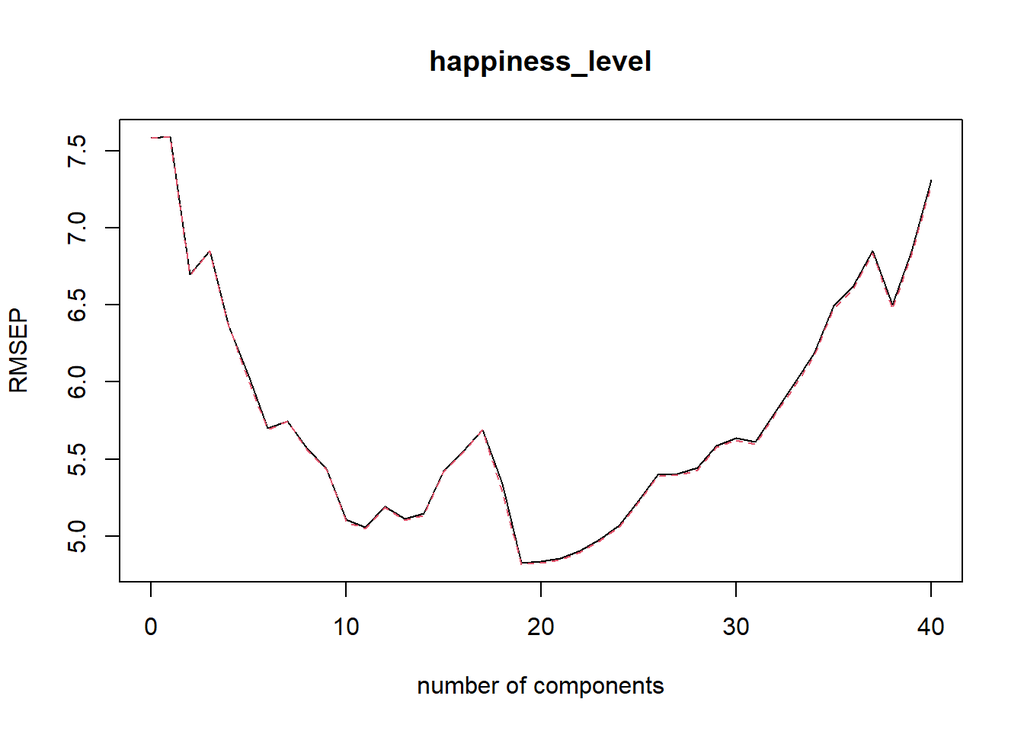

```r
validationplot(pcr_fit)
```

The minimum RMSE is achieved when we use 19 components.

```r
pcr_fit <- pcr(happiness_level ~ . -province,
               data = lifedata2015,
               scale = TRUE,
               ncomp = 19)
summary(pcr_fit)
```

```
## Data:    X dimension: 81 40
##  Y dimension: 81 1
## Fit method: svdpc
## Number of components considered: 19
## TRAINING: % variance explained
##                  1 comps  2 comps  3 comps  4 comps  5 comps  6 comps  7 comps
## X                 33.217    52.13    58.61    63.06    67.28    71.10    73.98
## happiness_level    2.339    26.62    27.94    44.79    55.72    56.07    57.85
##                  8 comps  9 comps  10 comps  11 comps  12 comps  13 comps
## X                  76.73    79.16     81.31     83.35     85.13     86.65
## happiness_level    60.82    63.14     66.85     67.15     67.50     68.60
##                  14 comps  15 comps  16 comps  17 comps  18 comps  19 comps
## X                   88.12     89.57     90.80     91.83     92.74     93.62
## happiness_level     69.02     69.44     71.35     71.63     77.56     77.60
```

# 2 K-Means Clustering

The function `kmeans()` performs K-means clustering in R. We begin with a simple simulated example in which there truly are two clusters in the data: the first 25 observations have a mean shift relative to the next 25 observations.

```r
set.seed(2)
x <- matrix(rnorm(50*2), ncol=2)
x[1:25,1]=x[1:25,1]+3
x[1:25,2]=x[1:25,2]-4
km.out <- kmeans(x,2,nstart=20)
km.out$cluster
```

```
##  [1] 1 1 1 1 1 1 1 1 1 1 1 1 1 1 1 1 1 1 1 1 1 1 1 1 1 2 2 2 2 2 2 2 2 2 2 2 2 2
## [39] 2 2 2 2 2 2 2 2 2 2 2 2
```

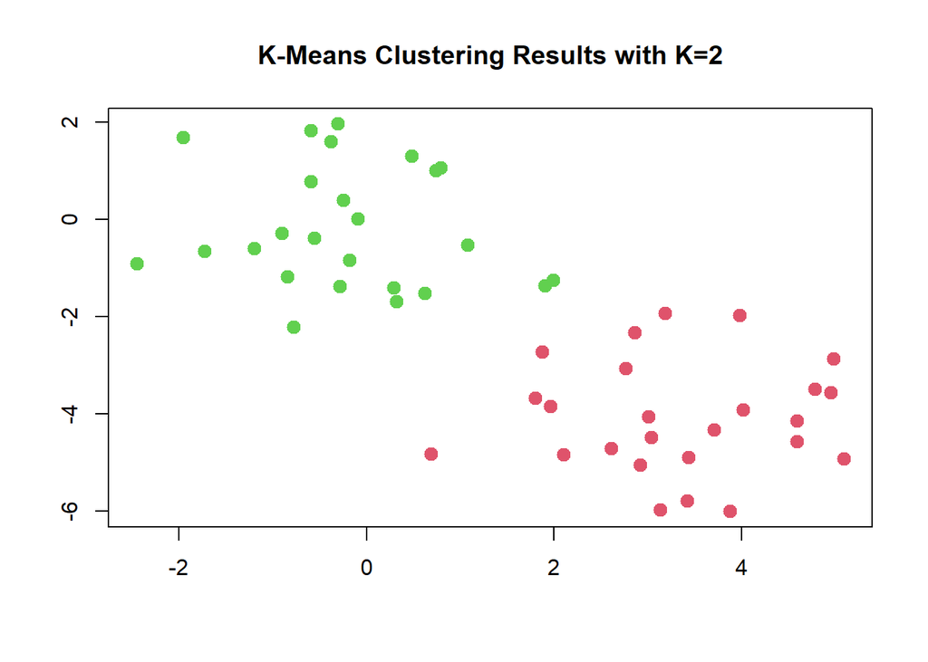

```r
plot(x, col=(km.out$cluster+1), main="K-Means Clustering Results with K=2", xlab="", ylab="", pch=20, cex=2)
```

In this example, we knew that there really were two clusters because we generated the data. However, for real data, in general we do not know the true number of clusters. We could instead have performed K-means clustering on this example with K = 3.

```r
set.seed(4)
km.out <- kmeans(x,3,nstart=20)
km.out
```

```
## K-means clustering with 3 clusters of sizes 17, 23, 10
##
## Cluster means:
##         [,1]        [,2]
## 1  3.7789567 -4.56200798
## 2 -0.3820397 -0.08740753
## 3  2.3001545 -2.69622023
##
## Clustering vector:
##  [1] 1 3 1 3 1 1 1 3 1 3 1 3 1 3 1 3 1 1 1 1 1 3 1 1 1 2 2 2 2 2 2 2 2 2 2 2 2 2
## [39] 2 2 2 2 2 3 2 3 2 2 2 2
##
## Within cluster sum of squares by cluster:
## [1] 25.74089 52.67700 19.56137
##  (between_SS / total_SS =  79.3 %)
##
## Available components:
##
## [1] "cluster"      "centers"      "totss"        "withinss"     "tot.withinss"
## [6] "betweenss"    "size"         "iter"         "ifault"
```

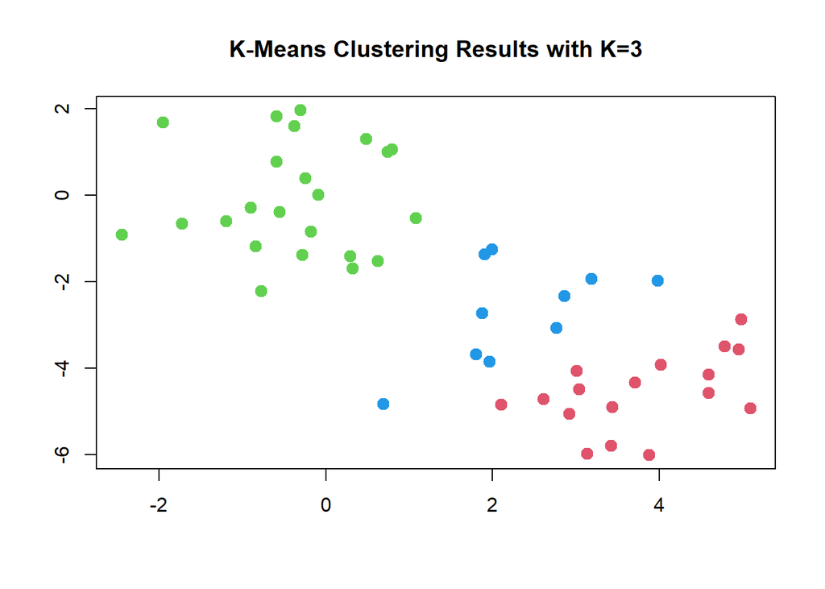

```r
plot(x, col=(km.out$cluster+1), main="K-Means Clustering Results with K=3", xlab="", ylab="", pch=20, cex=2)
```

When K = 3, K-means clustering splits up the two clusters. It is strongly recommended to run K-means clustering with a large value of nstart, such as 20 or 50, since otherwise an undesirable local optimum may be obtained.

```r
set.seed(3)
km.out <- kmeans(x,3,nstart=1)
km.out$tot.withinss
```

```
## [1] 97.97927
```

```r
km.out <- kmeans(x,3,nstart=20)
km.out$tot.withinss
```

```
## [1] 97.97927
```

## 2.1 Example: Bodydata

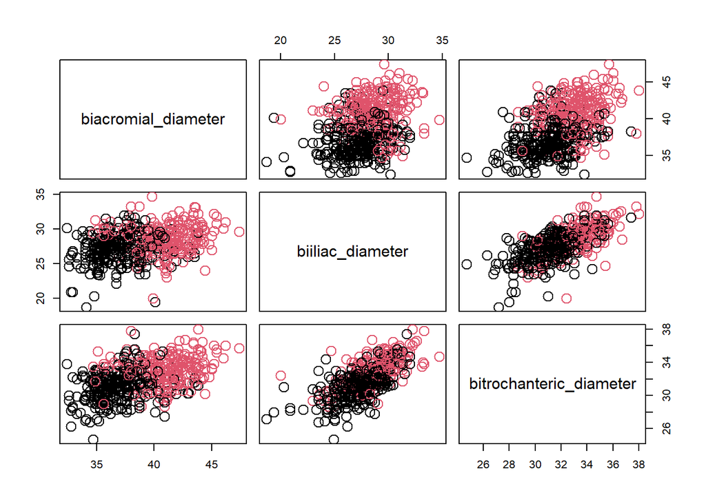

```r
km.out <- kmeans(bodydata,2,nstart=20)
plot(bodydata[,1:3],col=(km.out$cluster),cex=2)
```

Plot clustering based on weight and height and compare to the actual gender factor:

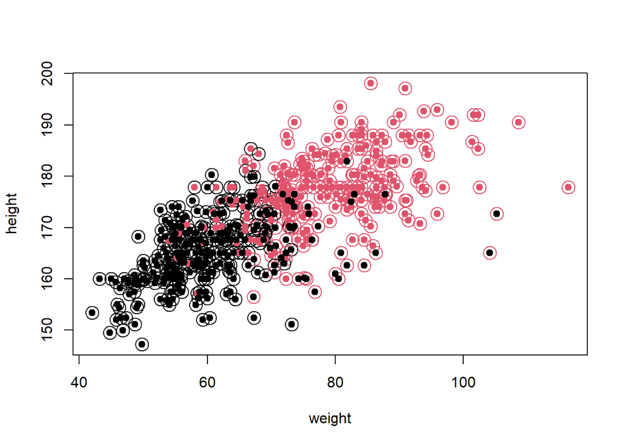

```r
# Large blank circles are the resulting clusters
plot(bodydata[,22:23],col=(km.out$cluster),cex=2)
# put dots inside circles representing observed gender
# red = men, black = women
points(body[,23:24], col=c(1,2)[body$gender], pch=19, cex=1)
```

```r
observed_class <- c(1,2)[body$gender]
km_cluster <- km.out$cluster
ratio <- sum(observed_class == km_cluster)/nrow(bodydata)
ratio
```

```
## [1] 0.8402367
```

84% of observations seem to be clustered correctly. Note that if know the clusters we’d not apply K-Means cluster method. THis was just for demonstration purposes. When we know the labels there are better classification methods which we’ve discussed in our previous classes.

# 3 Hierarchical Clustering

The `hclust()` function implements hierarchical clustering in R.

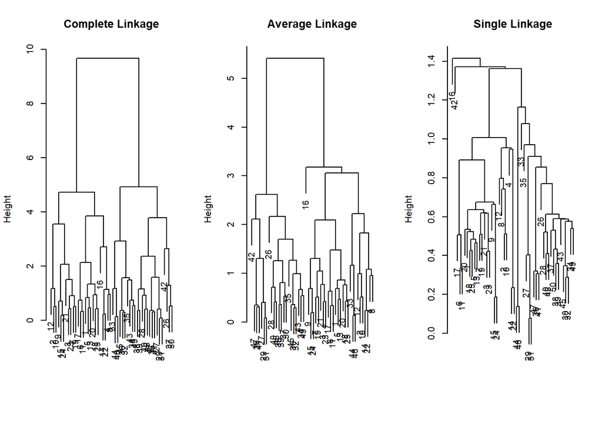

```r
hc.complete <- hclust(dist(x), method="complete")
hc.average <- hclust(dist(x), method="average")
hc.single <- hclust(dist(x), method="single")
par(mfrow=c(1,3))
plot(hc.complete,main="Complete Linkage", xlab="", sub="", cex=.9)
plot(hc.average, main="Average Linkage", xlab="", sub="", cex=.9)
plot(hc.single, main="Single Linkage", xlab="", sub="", cex=.9)
```

```r
cutree(hc.complete, 2)
```

```
##  [1] 1 1 1 1 1 1 1 1 1 1 1 1 1 1 1 1 1 1 1 1 1 1 1 1 1 2 2 2 2 2 2 2 2 2 2 2 2 2
## [39] 2 2 2 2 2 2 2 2 2 2 2 2
```

```r
cutree(hc.average, 2)
```

```
##  [1] 1 1 1 1 1 1 1 1 1 1 1 1 1 1 1 1 1 1 1 1 1 1 1 1 1 2 2 2 2 2 2 2 1 2 2 2 2 2
## [39] 2 2 2 2 2 1 2 1 2 2 2 2
```

```r
cutree(hc.single, 2)
```

```
##  [1] 1 1 1 1 1 1 1 1 1 1 1 1 1 1 1 2 1 1 1 1 1 1 1 1 1 1 1 1 1 1 1 1 1 1 1 1 1 1
## [39] 1 1 1 1 1 1 1 1 1 1 1 1
```

```r
cutree(hc.single, 4)
```

```
##  [1] 1 1 1 1 1 1 1 1 1 1 1 1 1 1 1 2 1 1 1 1 1 1 1 1 1 3 3 3 3 3 3 3 3 3 3 3 3 3
## [39] 3 3 3 4 3 3 3 3 3 3 3 3
```

To scale the variables before performing hierarchical clustering of the observations, we use the scale() function:

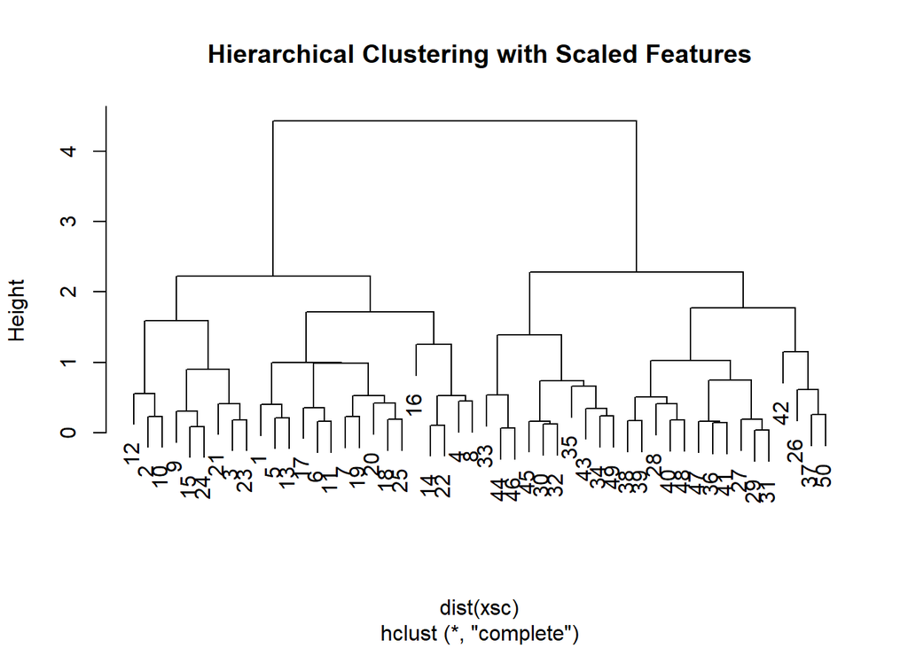

```r
xsc=scale(x)
plot(hclust(dist(xsc), method="complete"), main="Hierarchical Clustering with Scaled Features")
```